# Devoir Econométrie L3 S2 Forecasting Crowds Counter

# data

```r
#############################################
### Importation et création des variables ###
#############################################
data<-read.csv("CrowdCounterBDD.csv",sep=";",dec=",")
datanew<-read_xlsx("CrowdCounterNEWdataBIS.xlsx")
head(data)
```

```
    nb t       date jour mois   an  joursem vacances
1  462 0 02/01/2010    2    1 2010   Samedi        0
2 1021 0 04/01/2010    4    1 2010    Lundi        0
3  735 0 05/01/2010    5    1 2010    Mardi        0
4  604 0 06/01/2010    6    1 2010 Mercredi        0
5  466 0 07/01/2010    7    1 2010    Jeudi        0
6  434 0 08/01/2010    8    1 2010 Vendredi        0
```

# data and descriptive statistics

Nous n’utiliserons pas la variable Date car toutes les autres variables se forment avec Date.

```r
#data$apferie<-0
#data[c(1,80,102,107,110,118,161,254,260,299,304,400,432,440,440,466,492,558,566,603,693,711,723,731,771,797,863,908,913,989,1014,1019,1027,1100,1166,1173,1210,1215,1303,1316,1321,1338,1346,1375,1402,1468,1475,1512,1517,1597,1618,1623,1627,1635,1677,1704,1778,1815,1820,1893,1925,1933,1983,2009,2075,2083,2216,2227,2232,2246,2254,2287,2313,2379,2387,2424,2428,2505,2539,2533,2534,2542),10]<-1
data$apvac<-0
data[c(44,91,203,256,304,358,405,509,559,610,669,715,813,868,917,965,1012,1114,1167,1218,1272,1318,1416,1468,1519,1573,1624,1717,1770,1821,1863,1910,2023,2076,2128,2174,2221,2329,2382,2433,2487,2536),9]<-1
data$apvac=as.factor(data$apvac)
data$jour2<-data$jour
data$vacances=as.factor(data$vacances)
data$mois=as.factor(data$mois)
data$an=as.factor(data$an)
data$t=as.factor(data$t)
data$jour2=as.factor(data$jour2)
data$joursem2 <- factor(data$joursem, levels = c("Lundi",
  "Mardi", "Mercredi", "Jeudi", "Vendredi",
  "Samedi"))
table(data$joursem)
```

```
##
##    Jeudi    Lundi    Mardi Mercredi   Samedi Vendredi
##      421      412      428      431      429      429
```

On a transformé les variables en factor et mis la variable joursem avec les jours dans le bon ordre. De plus, nous avons crée la variable apvac qui prend 1 pour les jours de rentrée et 0 sinon.

```r
str(data)
```

```
## 'data.frame':    2550 obs. of  11 variables:
##  $ nb      : int  462 1021 735 604 466 434 192 535 395 374 ...
##  $ t       : Factor w/ 100 levels "0","1","2","3",..: 1 1 1 1 1 1 1 1 1 1 ...
##  $ date    : Factor w/ 2550 levels "01/02/2010","01/02/2011",..: 65 237 323 406 491 578 656 826 905 992 ...
##  $ jour    : int  2 4 5 6 7 8 9 11 12 13 ...
##  $ mois    : Factor w/ 12 levels "1","2","3","4",..: 1 1 1 1 1 1 1 1 1 1 ...
##  $ an      : Factor w/ 9 levels "2010","2011",..: 1 1 1 1 1 1 1 1 1 1 ...
##  $ joursem : Factor w/ 6 levels "Jeudi","Lundi",..: 5 2 3 4 1 6 5 2 3 4 ...
##  $ vacances: Factor w/ 2 levels "0","1": 1 1 1 1 1 1 1 1 1 1 ...
##  $ apvac   : Factor w/ 2 levels "0","1": 1 1 1 1 1 1 1 1 1 1 ...
##  $ jour2   : Factor w/ 31 levels "1","2","3","4",..: 2 4 5 6 7 8 9 11 12 13 ...
##  $ joursem2: Factor w/ 6 levels "Lundi","Mardi",..: 6 1 2 3 4 5 6 1 2 3 ...
```

```r
attach(data)
```

Premier graphique sur la variable joursem :

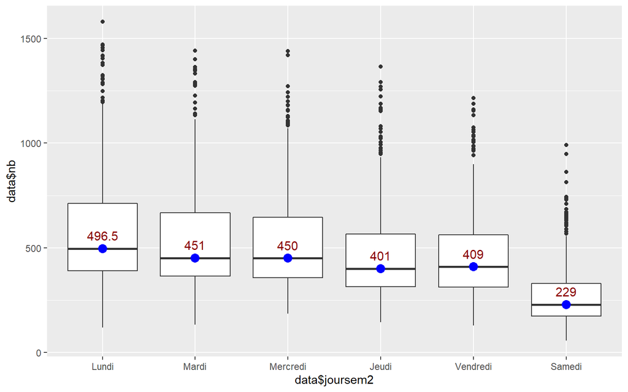

```r
ggplot(data=data)+
       aes(x=data$joursem2,y=data$nb)+
  geom_boxplot()+
  stat_summary(aes(label=..y..),fun.y = median,
               geom="text", size=4, color="darkred", vjust=-0.9)+
  stat_summary(fun.y=median, geom="point",size=3.5,color="blue", fill="blue")
```

On retrouve une relation décroissante entre le nombre de personnes et le jour de la semaine. De plus, le samedi a un nombre de clients très faible.

Second graphique sur la variable an :

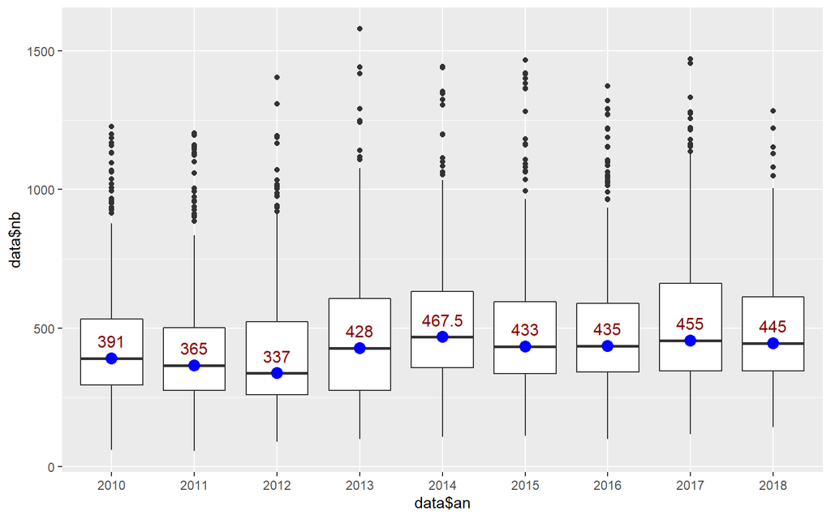

```r
ggplot(data=data)+
       aes(x=data$an,y=data$nb)+
  geom_boxplot()+
  stat_summary(aes(label=..y..),fun.y = median,
               geom="text", size=4, color="darkred", vjust=-0.9)+
  stat_summary(fun.y=median, geom="point",size=3.5,color="blue", fill="blue")
```

Troisième graphique sur la variable jour :

```r
b<-mean(data$nb[data$mois==1])
c<-mean(data$nb[data$mois==2])
d<-mean(data$nb[data$mois==3])
e<-mean(data$nb[data$mois==4])
f<-mean(data$nb[data$mois==5])
g<-mean(data$nb[data$mois==6])
h<-mean(data$nb[data$mois==7])
i<-mean(data$nb[data$mois==8])
j<-mean(data$nb[data$mois==9])
k<-mean(data$nb[data$mois==10])
l<-mean(data$nb[data$mois==11])
m<-mean(data$nb[data$mois==12])
(b+c+d+e+f+g+h+i+j+k+l+m)/12
```

```
## [1] 479.8841
```

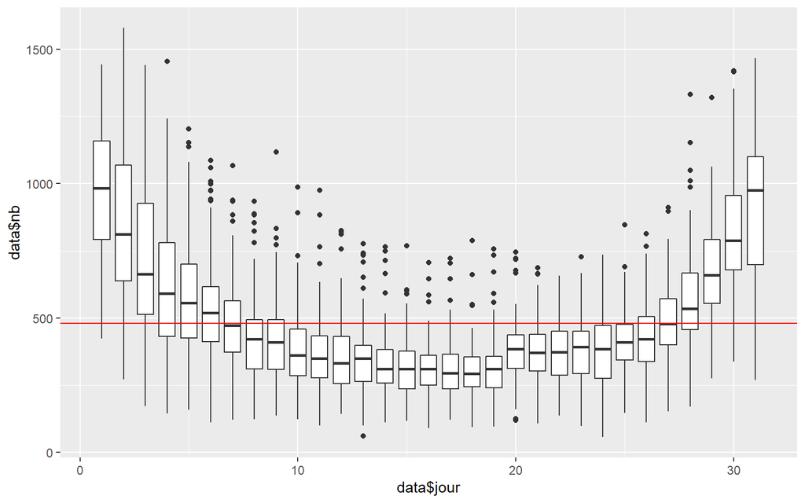

```r
ggplot(data=data)+
       aes(x=data$jour,y=data$nb,group=jour)+
  geom_boxplot()+
  geom_hline(yintercept=480,color="red")
```

```r
data$jourcarre<-data$jour^2
data$jourcarre=as.factor(data$jourcarre)
```

On reconnait une forme non linèaire qui ressemble à une fonction du second degré(Cela est surement du au fait que les personnes recoivent leurs salaires en fin et début de mois). De plus, pour tester un modèle avec variable dummy, on a calculé la moyenne générale de tous les mois donc on sépare les jours avec une moyenne plus élevée des jours avec une moyenne plus basse. On crée également la variable jour au carré que nous pourrons utiliser dans nos modèles plus tard.

Quatrième graphique sur la variable mois

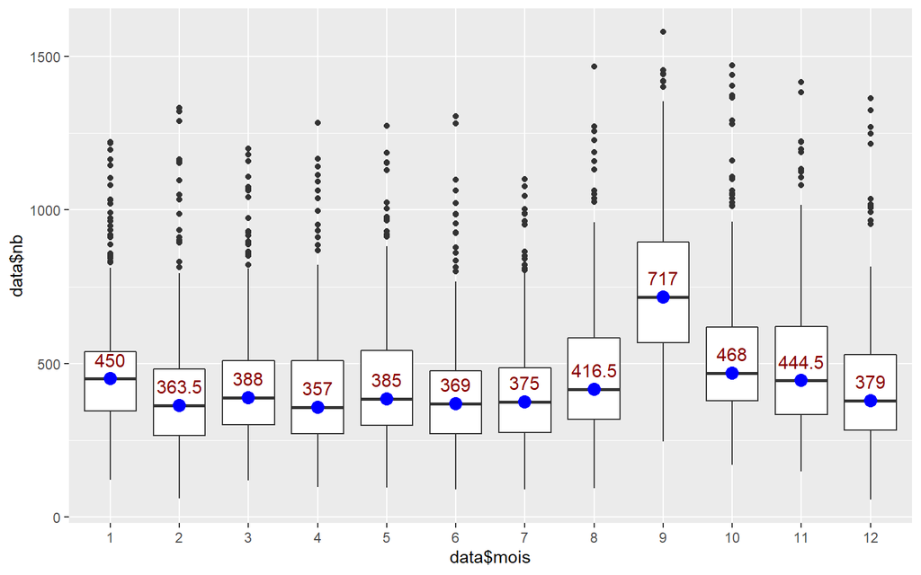

```r
ggplot(data=data)+
       aes(x=data$mois,y=data$nb)+
  geom_boxplot()+
    stat_summary(aes(label=..y..),fun.y = median,
               geom="text", size=4, color="darkred", vjust=-0.9)+
  stat_summary(fun.y=median, geom="point",size=3.5,color="blue", fill="blue")
```

Le mois de septembre semble clairement se démarquer des autres.

Cinquième graphique sur la variable t :

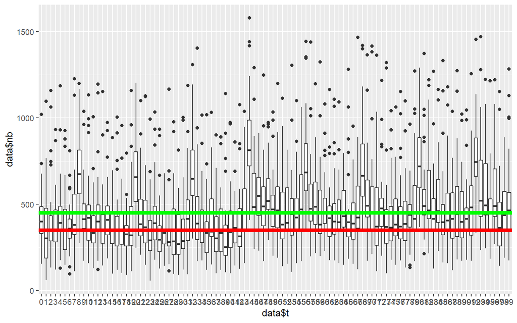

```r
ggplot(data=data)+
       aes(x=data$t,y=data$nb)+
  geom_boxplot()+
  geom_hline(yintercept=350,color="red",size=2)+
  geom_hline(yintercept=450,color="green",size=2)
```

On retrouve des temporalités mais il semble également y avoir une cassure à partir de septembre 2013 où la moyenne des données semblent plus haute(droite verte) à partir de ce mois-ci.

Sixième graphique sur la variable vacances :

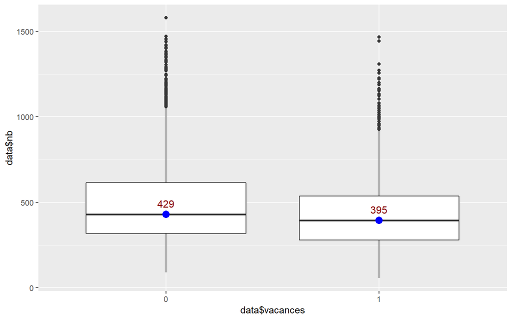

```r
ggplot(data=data)+
       aes(x=data$vacances,y=data$nb)+
  geom_boxplot()+
  stat_summary(aes(label=..y..),fun.y = median,
               geom="text", size=4, color="darkred", vjust=-0.9)+
  stat_summary(fun.y=median, geom="point",size=3.5,color="blue", fill="blue")
```

Petite différence, le fait d’être en vacances baisse un peu le nombre de clients.

Septième graphique sur la variable apvac :

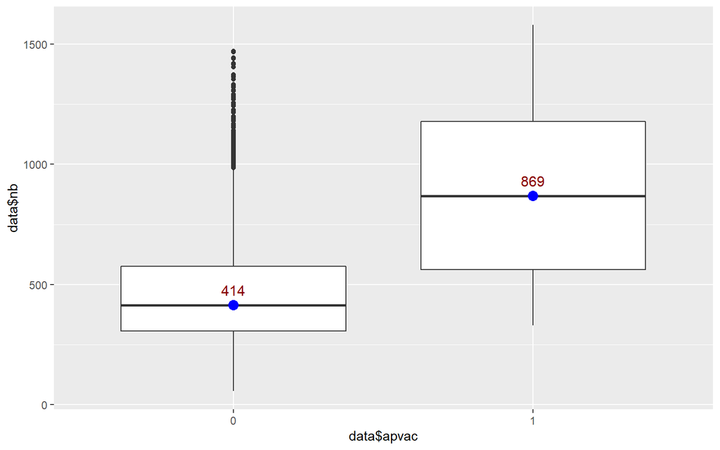

```r
ggplot(data=data)+
       aes(x=data$apvac,y=data$nb)+
  geom_boxplot()+
  stat_summary(aes(label=..y..),fun.y = median,
               geom="text", size=4, color="darkred", vjust=-0.9)+
  stat_summary(fun.y=median, geom="point",size=3.5,color="blue", fill="blue")
```

Beaucoup plus de monde à la rentrée mais c’est logique car c’est quasiment que des lundis et les lundis ont en moyenne plus de clients.

Création de nos dummies :

```r
data$joursemdummy<-ifelse(data$joursem=="Samedi",1,0)
data$joursemdummy=as.factor(data$joursemdummy)
#On sépare samedi des autres jours.
data$moisdummy<-ifelse(data$mois=="9",1,0)
data$moisdummy=as.factor(data$moisdummy)
#On sépare novembre et les autres mois.
data$jour2=as.numeric(data$jour2)
data$jourdummy<-data$jour2
data$jourdummy<-ifelse(data$jour2<=7 | data$jour2>=27,1,0)
data$jourdummy=as.factor(data$jourdummy)
#On sépare les jours au dessus et en dessous de la moyenne.
attach(data)
```

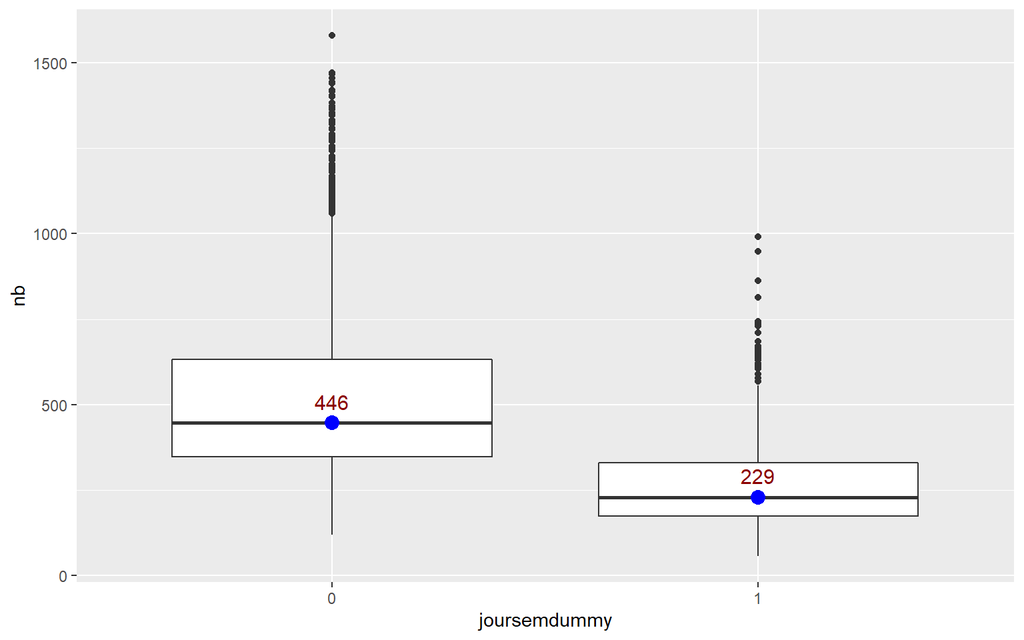

```r
ggplot(data=data)+
  aes(x=joursemdummy,y=nb,group=joursemdummy)+
  geom_boxplot()+
  stat_summary(aes(label=..y..),fun.y = median,
               geom="text", size=4, color="darkred", vjust=-0.9)+
  stat_summary(fun.y=median, geom="point",size=3.5,color="blue", fill="blue")
```

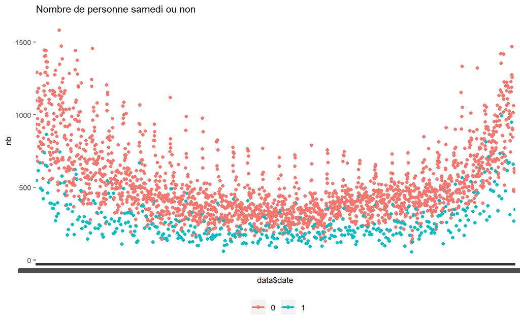

```r
a<-ggplot(data) + aes(y = nb,x=data$date)+
  geom_smooth(method="lm", se= F, size = 1, aes(colour=factor(joursemdummy))) + geom_point(aes(colour=factor(joursemdummy)))+
  ggtitle("Nombre de personne samedi ou non") +
  theme(axis.text = element_text(size=8),
        title=element_text(size=9),
        legend.position = "bottom",
        legend.title = element_blank())
a
```

Nette différence entre samedi et les autres jours.

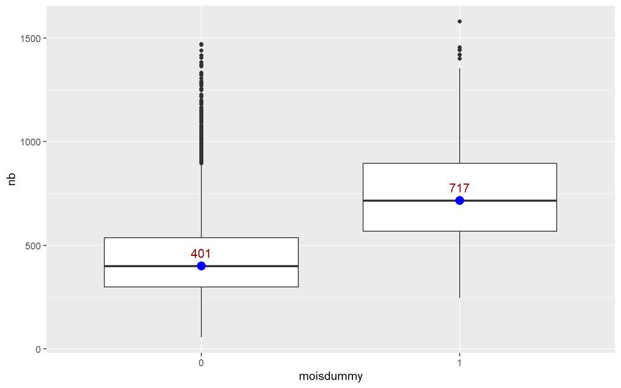

```r
ggplot(data=data)+
  aes(x=moisdummy,y=nb, group=moisdummy)+
  geom_boxplot()+
  stat_summary(aes(label=..y..),fun.y = median,
               geom="text", size=4, color="darkred", vjust=-0.9)+
  stat_summary(fun.y=median, geom="point",size=3.5,color="blue", fill="blue")
```

Nette difference entre septembre et les autres mois.

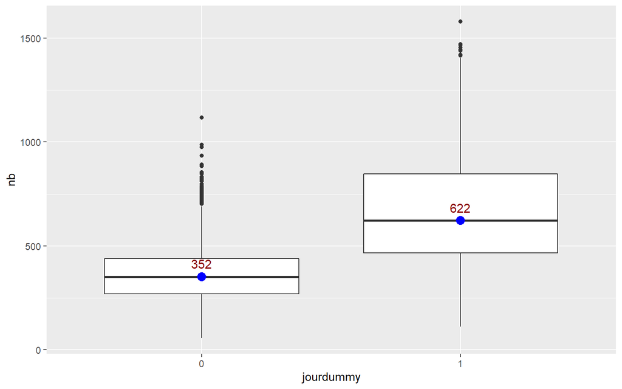

```r
ggplot(data=data)+
  aes(x=jourdummy,y=nb,group=jourdummy)+
  geom_boxplot()+
  stat_summary(aes(label=..y..),fun.y = median,
               geom="text", size=4, color="darkred", vjust=-0.9)+
  stat_summary(fun.y=median, geom="point",size=3.5,color="blue", fill="blue")
```

Egalement une difference entre les jours au dessus de la moyenne et ceux en dessous. Nos dummies semblent donc cohérentes.

Voila pour l’analyse des données et la création de variables dummies.Nous allons maintenant passer aux tests de différents modèles.

# models and estimation

On va tout d’abord regarder notre modèle avec les dummies :

```r
lmdummy<-lm(nb~joursemdummy+jourdummy+moisdummy+vacances,data=data)
summary(lmdummy)
```

```
##
## Call:
## lm(formula = nb ~ joursemdummy + jourdummy + moisdummy + vacances,
##     data = data)
##
## Residuals:
##     Min      1Q  Median      3Q     Max
## -503.37 -100.81  -11.87   73.96  798.51
##
## Coefficients:
##               Estimate Std. Error t value Pr(>|t|)
## (Intercept)    389.810      4.966  78.494  < 2e-16 ***
## joursemdummy1 -242.720      8.696 -27.911  < 2e-16 ***
## jourdummy1     306.562      6.714  45.659  < 2e-16 ***
## moisdummy1     292.441     12.094  24.181  < 2e-16 ***
## vacances1      -27.877      7.124  -3.913 9.36e-05 ***
## ---
## Signif. codes:  0 '***' 0.001 '**' 0.01 '*' 0.05 '.' 0.1 ' ' 1
##
## Residual standard error: 163.9 on 2545 degrees of freedom
## Multiple R-squared:  0.5801, Adjusted R-squared:  0.5794
## F-statistic: 878.9 on 4 and 2545 DF,  p-value: < 2.2e-16
```

Le R2 est plutôt bon et tous les coefficients sont significatifs, toutefois, pour un modèle de prédiction jour par jour, ce modèle ne semble pas vraiment adapté.

```r
lmdummy2c<-lm(nb~joursemdummy+jourcarre+moisdummy+vacances,data=data)
summary(lmdummy2c)
```

```
##
## Call:
## lm(formula = nb ~ joursemdummy + jourcarre + moisdummy + vacances,
##     data = data)
##
## Residuals:
##     Min      1Q  Median      3Q     Max
## -469.07  -78.91   -5.88   67.91  720.02
##
## Coefficients:
##               Estimate Std. Error t value Pr(>|t|)
## (Intercept)    993.789     16.434  60.473  < 2e-16 ***
## joursemdummy1 -241.935      6.914 -34.994  < 2e-16 ***
## jourcarre4    -124.062     21.518  -5.766 9.13e-09 ***
## jourcarre9    -249.504     21.508 -11.601  < 2e-16 ***
## jourcarre16   -348.477     21.509 -16.201  < 2e-16 ***
## jourcarre25   -387.803     21.671 -17.895  < 2e-16 ***
## jourcarre36   -430.457     21.560 -19.965  < 2e-16 ***
## jourcarre49   -482.330     21.455 -22.481  < 2e-16 ***
## jourcarre64   -536.012     21.971 -24.396  < 2e-16 ***
## jourcarre81   -550.444     21.561 -25.530  < 2e-16 ***
## jourcarre100  -580.365     21.563 -26.915  < 2e-16 ***
## jourcarre121  -602.069     21.910 -27.479  < 2e-16 ***
## jourcarre144  -611.887     21.455 -28.519  < 2e-16 ***
## jourcarre169  -625.206     21.616 -28.924  < 2e-16 ***
## jourcarre196  -636.457     21.925 -29.029  < 2e-16 ***
## jourcarre225  -651.953     21.915 -29.749  < 2e-16 ***
## jourcarre256  -652.303     21.454 -30.404  < 2e-16 ***
## jourcarre289  -650.707     21.616 -30.103  < 2e-16 ***
## jourcarre324  -657.404     21.508 -30.566  < 2e-16 ***
## jourcarre361  -650.066     21.456 -30.298  < 2e-16 ***
## jourcarre400  -581.801     21.562 -26.982  < 2e-16 ***
## jourcarre441  -587.686     21.565 -27.252  < 2e-16 ***
## jourcarre484  -590.717     21.516 -27.455  < 2e-16 ***
## jourcarre529  -582.874     21.412 -27.222  < 2e-16 ***
## jourcarre576  -584.101     21.572 -27.076  < 2e-16 ***
## jourcarre625  -544.144     22.049 -24.679  < 2e-16 ***
## jourcarre676  -525.711     21.471 -24.484  < 2e-16 ***
## jourcarre729  -470.472     21.528 -21.854  < 2e-16 ***
## jourcarre784  -380.810     21.583 -17.644  < 2e-16 ***
## jourcarre841  -291.702     21.922 -13.307  < 2e-16 ***
## jourcarre900  -140.193     21.859  -6.413 1.69e-10 ***
## jourcarre961   -11.288     24.648  -0.458    0.647
## moisdummy1     291.311      9.623  30.273  < 2e-16 ***
## vacances1      -40.432      5.756  -7.024 2.76e-12 ***
## ---
## Signif. codes:  0 '***' 0.001 '**' 0.01 '*' 0.05 '.' 0.1 ' ' 1
##
## Residual standard error: 130.3 on 2516 degrees of freedom
## Multiple R-squared:  0.7378, Adjusted R-squared:  0.7343
## F-statistic: 214.5 on 33 and 2516 DF,  p-value: < 2.2e-16
```

```r
data$jour<-as.factor(data$jour)
lmdummy2<-lm(nb~joursemdummy+jour+moisdummy+vacances,data=data)
summary(lmdummy2)
```

```
##
## Call:
## lm(formula = nb ~ joursemdummy + jour + moisdummy + vacances,
##     data = data)
##
## Residuals:
##     Min      1Q  Median      3Q     Max
## -469.07  -78.91   -5.88   67.91  720.02
##
## Coefficients:
##               Estimate Std. Error t value Pr(>|t|)
## (Intercept)    993.789     16.434  60.473  < 2e-16 ***
## joursemdummy1 -241.935      6.914 -34.994  < 2e-16 ***
## jour2         -124.062     21.518  -5.766 9.13e-09 ***
## jour3         -249.504     21.508 -11.601  < 2e-16 ***
## jour4         -348.477     21.509 -16.201  < 2e-16 ***
## jour5         -387.803     21.671 -17.895  < 2e-16 ***
## jour6         -430.457     21.560 -19.965  < 2e-16 ***
## jour7         -482.330     21.455 -22.481  < 2e-16 ***
## jour8         -536.012     21.971 -24.396  < 2e-16 ***
## jour9         -550.444     21.561 -25.530  < 2e-16 ***
## jour10        -580.365     21.563 -26.915  < 2e-16 ***
## jour11        -602.069     21.910 -27.479  < 2e-16 ***
## jour12        -611.887     21.455 -28.519  < 2e-16 ***
## jour13        -625.206     21.616 -28.924  < 2e-16 ***
## jour14        -636.457     21.925 -29.029  < 2e-16 ***
## jour15        -651.953     21.915 -29.749  < 2e-16 ***
## jour16        -652.303     21.454 -30.404  < 2e-16 ***
## jour17        -650.707     21.616 -30.103  < 2e-16 ***
## jour18        -657.404     21.508 -30.566  < 2e-16 ***
## jour19        -650.066     21.456 -30.298  < 2e-16 ***
## jour20        -581.801     21.562 -26.982  < 2e-16 ***
## jour21        -587.686     21.565 -27.252  < 2e-16 ***
## jour22        -590.717     21.516 -27.455  < 2e-16 ***
## jour23        -582.874     21.412 -27.222  < 2e-16 ***
## jour24        -584.101     21.572 -27.076  < 2e-16 ***
## jour25        -544.144     22.049 -24.679  < 2e-16 ***
## jour26        -525.711     21.471 -24.484  < 2e-16 ***
## jour27        -470.472     21.528 -21.854  < 2e-16 ***
## jour28        -380.810     21.583 -17.644  < 2e-16 ***
## jour29        -291.702     21.922 -13.307  < 2e-16 ***
## jour30        -140.193     21.859  -6.413 1.69e-10 ***
## jour31         -11.288     24.648  -0.458    0.647
## moisdummy1     291.311      9.623  30.273  < 2e-16 ***
## vacances1      -40.432      5.756  -7.024 2.76e-12 ***
## ---
## Signif. codes:  0 '***' 0.001 '**' 0.01 '*' 0.05 '.' 0.1 ' ' 1
##
## Residual standard error: 130.3 on 2516 degrees of freedom
## Multiple R-squared:  0.7378, Adjusted R-squared:  0.7343
## F-statistic: 214.5 on 33 and 2516 DF,  p-value: < 2.2e-16
```

Ce modèle en mettant juste les jours en facteurs semble bon, tous les coefficients sont significatifs(sauf jour31 ce qui est logique car peu de mois ont un 31e jour) et le R2 est largement meilleur que pour le modèle lmdummy mais il ne semble pas y avoir de différence entre le fait de mettre les jours au carré ou non. De plus, les previsions de ce modèle sont bonnes. Exemple pour le 6 juin où la vraie valeur est de 563 : Prevision = 993.789-430.457 environ égale à 563

Même si ce modèle est bon, il semble qu’utiliser toutes les variables en facteurs soit meilleur pour la précision de nos prédictions malgré le fait que ça ajoute beaucoup de coefficients à notre modèle.

On crée la variable dummy qui se construit à la suite de l’analyse des données pour la variable t, où il semble y avoir une différence de moyenne à partir de septembre 2013.

```r
data$t_rec <- fct_recode(data$t,
               "1" = "0",
               "1" = "2",
               "1" = "3",
               "1" = "4",
               "1" = "5",
               "1" = "6",
               "1" = "7",
               "1" = "8",
               "1" = "9",
               "1" = "10",
               "1" = "11",
               "1" = "12",
               "1" = "13",
               "1" = "14",
               "1" = "15",
               "1" = "16",
               "1" = "17",
               "1" = "18",
               "1" = "19",
               "1" = "20",
               "1" = "21",
               "1" = "22",
               "1" = "23",
               "1" = "24",
               "1" = "25",
               "1" = "26",
               "1" = "27",
               "1" = "28",
               "1" = "29",
               "1" = "30",
               "1" = "31",
               "1" = "32",
               "1" = "33",
               "1" = "34",
               "1" = "35",
               "1" = "36",
               "1" = "37",
               "1" = "38",
               "1" = "39",
               "1" = "40",
               "1" = "41",
               "1" = "42",
               "1" = "43",
               "1" = "44",
               "0" = "45",
               "0" = "46",
               "0" = "47",
               "0" = "48",
               "0" = "49",
               "0" = "50",
               "0" = "51",
               "0" = "52",
               "0" = "53",
               "0" = "54",
               "0" = "55",
               "0" = "56",
               "0" = "57",
               "0" = "58",
               "0" = "59",
               "0" = "60",
               "0" = "61",
               "0" = "62",
               "0" = "63",
               "0" = "64",
               "0" = "65",
               "0" = "66",
               "0" = "67",
               "0" = "68",
               "0" = "69",
               "0" = "70",
               "0" = "71",
               "0" = "72",
               "0" = "73",
               "0" = "74",
               "0" = "75",
               "0" = "76",
               "0" = "77",
               "0" = "78",
               "0" = "79",
               "0" = "80",
               "0" = "81",
               "0" = "82",
               "0" = "83",
               "0" = "84",
               "0" = "85",
               "0" = "86",
               "0" = "87",
               "0" = "88",
               "0" = "89",
               "0" = "90",
               "0" = "91",
               "0" = "92",
               "0" = "93",
               "0" = "94",
               "0" = "95",
               "0" = "96",
               "0" = "97",
               "0" = "98",
               "0" = "99")
data$t_rec=as.factor(data$t_rec)
```

```r
data$jour <- factor(data$jour,levels=c("2","3","4","5","6","7","8","9","10","11","12","13","14","15","16","17","18","19","20","21","22","23","24","25","26","27","28","29","30","31","1"))
data$joursem<-factor(data$joursem, levels =c("Samedi","Lundi",
  "Mardi", "Mercredi", "Jeudi", "Vendredi"))

lm1<-lm(nb~data$jour+mois+joursem+an+vacances+data$t_rec+apvac,data=data)
summary(lm1)
```

```
##
## Call:
## lm(formula = nb ~ data$jour + mois + joursem + an + vacances +
##     data$t_rec + apvac, data = data)
##
## Residuals:
##     Min      1Q  Median      3Q     Max
## -425.89  -60.25   -5.84   50.97  658.79
##
## Coefficients:
##                 Estimate Std. Error t value Pr(>|t|)
## (Intercept)      619.481     15.424  40.164  < 2e-16 ***
## data$jour3      -124.186     16.347  -7.597 4.27e-14 ***
## data$jour4      -228.887     16.375 -13.978  < 2e-16 ***
## data$jour5      -259.257     16.512 -15.701  < 2e-16 ***
## data$jour6      -298.791     16.414 -18.203  < 2e-16 ***
## data$jour7      -354.046     16.324 -21.689  < 2e-16 ***
## data$jour8      -406.294     16.804 -24.178  < 2e-16 ***
## data$jour9      -418.213     16.430 -25.455  < 2e-16 ***
## data$jour10     -446.874     16.443 -27.177  < 2e-16 ***
## data$jour11     -464.751     16.762 -27.726  < 2e-16 ***
## data$jour12     -481.681     16.340 -29.479  < 2e-16 ***
## data$jour13     -491.505     16.498 -29.792  < 2e-16 ***
## data$jour14     -508.600     16.786 -30.299  < 2e-16 ***
## data$jour15     -511.305     16.774 -30.481  < 2e-16 ***
## data$jour16     -516.511     16.348 -31.595  < 2e-16 ***
## data$jour17     -515.707     16.493 -31.267  < 2e-16 ***
## data$jour18     -525.744     16.381 -32.094  < 2e-16 ***
## data$jour19     -518.067     16.321 -31.742  < 2e-16 ***
## data$jour20     -446.571     16.425 -27.189  < 2e-16 ***
## data$jour21     -451.707     16.420 -27.509  < 2e-16 ***
## data$jour22     -459.113     16.352 -28.077  < 2e-16 ***
## data$jour23     -448.120     16.276 -27.533  < 2e-16 ***
## data$jour24     -450.855     16.408 -27.477  < 2e-16 ***
## data$jour25     -412.416     16.853 -24.472  < 2e-16 ***
## data$jour26     -391.945     16.325 -24.009  < 2e-16 ***
## data$jour27     -337.677     16.360 -20.641  < 2e-16 ***
## data$jour28     -246.706     16.422 -15.023  < 2e-16 ***
## data$jour29     -158.944     16.725  -9.504  < 2e-16 ***
## data$jour30       -7.192     16.687  -0.431 0.666513
```

[output cut: 20 more lines]

```
## an2013             9.540      9.513   1.003 0.316065
## an2014           -11.570     17.510  -0.661 0.508846
## an2015           -33.117     17.498  -1.893 0.058534 .
## an2016           -27.080     17.493  -1.548 0.121750
## an2017            -1.134     17.513  -0.065 0.948355
## an2018             5.028     19.585   0.257 0.797400
## vacances1        -38.162      6.293  -6.064 1.53e-09 ***
## data$t_rec0       87.521     15.189   5.762 9.32e-09 ***
## apvac1           174.126     17.416   9.998  < 2e-16 ***
## ---
## Signif. codes:  0 '***' 0.001 '**' 0.01 '*' 0.05 '.' 0.1 ' ' 1
##
## Residual standard error: 107.1 on 2492 degrees of freedom
## Multiple R-squared:  0.8244, Adjusted R-squared:  0.8204
## F-statistic: 205.2 on 57 and 2492 DF,  p-value: < 2.2e-16
```

Essayons avec la variable nb au log

```r
data$lognb<-log(data$nb)
attach(data)
lm1<-lm(lognb~jour+mois+joursem+an+vacances+t_rec+apvac,data=data)
summary(lm1)
```

```
##
## Call:
## lm(formula = lognb ~ jour + mois + joursem + an + vacances +
##     t_rec + apvac, data = data)
##
## Residuals:
##      Min       1Q   Median       3Q      Max
## -1.05586 -0.10803  0.00959  0.11740  0.79566
##
## Coefficients:
##                  Estimate Std. Error t value Pr(>|t|)
## (Intercept)      6.122701   0.028483 214.962  < 2e-16 ***
## jour3           -0.188855   0.030188  -6.256 4.64e-10 ***
## jour4           -0.349888   0.030240 -11.570  < 2e-16 ***
## jour5           -0.395996   0.030492 -12.987  < 2e-16 ***
## jour6           -0.465496   0.030312 -15.357  < 2e-16 ***
## jour7           -0.569807   0.030145 -18.902  < 2e-16 ***
## jour8           -0.683486   0.031032 -22.025  < 2e-16 ***
## jour9           -0.730805   0.030340 -24.087  < 2e-16 ***
## jour10          -0.784884   0.030365 -25.849  < 2e-16 ***
## jour11          -0.848747   0.030954 -27.419  < 2e-16 ***
## jour12          -0.881714   0.030174 -29.221  < 2e-16 ***
## jour13          -0.929173   0.030466 -30.498  < 2e-16 ***
## jour14          -0.948785   0.030998 -30.608  < 2e-16 ***
## jour15          -0.961284   0.030977 -31.032  < 2e-16 ***
## jour16          -0.982620   0.030190 -32.548  < 2e-16 ***
## jour17          -0.977573   0.030458 -32.096  < 2e-16 ***
## jour18          -1.008207   0.030251 -33.328  < 2e-16 ***
## jour19          -0.986607   0.030139 -32.735  < 2e-16 ***
## jour20          -0.770961   0.030331 -25.418  < 2e-16 ***
## jour21          -0.784234   0.030323 -25.863  < 2e-16 ***
## jour22          -0.792616   0.030197 -26.248  < 2e-16 ***
## jour23          -0.784978   0.030056 -26.117  < 2e-16 ***
## jour24          -0.804248   0.030301 -26.542  < 2e-16 ***
## jour25          -0.675537   0.031121 -21.707  < 2e-16 ***
## jour26          -0.638783   0.030147 -21.189  < 2e-16 ***
## jour27          -0.507877   0.030211 -16.811  < 2e-16 ***
## jour28          -0.347859   0.030326 -11.471  < 2e-16 ***
## jour29          -0.194143   0.030885  -6.286 3.83e-10 ***
## jour30           0.013365   0.030816   0.434   0.6645
```

[output cut: 20 more lines]

```
## an2013          -0.019060   0.017567  -1.085   0.2780
## an2014          -0.081794   0.032336  -2.529   0.0115 *
## an2015          -0.134460   0.032314  -4.161 3.28e-05 ***
## an2016          -0.126479   0.032305  -3.915 9.28e-05 ***
## an2017          -0.073593   0.032340  -2.276   0.0230 *
## an2018          -0.051970   0.036167  -1.437   0.1509
## vacances1       -0.102424   0.011621  -8.814  < 2e-16 ***
## t_rec0           0.268109   0.028049   9.559  < 2e-16 ***
## apvac1           0.176591   0.032162   5.491 4.41e-08 ***
## ---
## Signif. codes:  0 '***' 0.001 '**' 0.01 '*' 0.05 '.' 0.1 ' ' 1
##
## Residual standard error: 0.1978 on 2492 degrees of freedom
## Multiple R-squared:  0.8543, Adjusted R-squared:  0.8509
## F-statistic: 256.3 on 57 and 2492 DF,  p-value: < 2.2e-16
```

On a largement amélioré le R2 et rendu plus de coefficients significatifs.On voit que la variable t_rec qui sépare la cassure vu grâce à l’analyse des données est significative, il faut tester si cela rend le modèle instable ou non avec un test de CHOW.

```r
data1<-data[data$t_rec==0,]
data2<-data[data$t_rec==1,]

lm1bis<-lm(lognb~data2$jour+data2$mois+data2$joursem+data2$vacances+data2$an+data2$apvac,data=data2)
summary(lm1bis)
```

```
##
## Call:
## lm(formula = lognb ~ data2$jour + data2$mois + data2$joursem +
##     data2$vacances + data2$an + data2$apvac, data = data2)
##
## Residuals:
##      Min       1Q   Median       3Q      Max
## -0.89690 -0.11896  0.01149  0.12023  0.75618
##
## Coefficients:
##                        Estimate Std. Error t value Pr(>|t|)
## (Intercept)            6.090279   0.043377 140.403  < 2e-16 ***
## data2$jour3           -0.236663   0.048097  -4.921 9.97e-07 ***
## data2$jour4           -0.353259   0.048237  -7.323 4.70e-13 ***
## data2$jour5           -0.425471   0.048209  -8.826  < 2e-16 ***
## data2$jour6           -0.495770   0.048006 -10.327  < 2e-16 ***
## data2$jour7           -0.607977   0.048186 -12.617  < 2e-16 ***
## data2$jour8           -0.700536   0.049337 -14.199  < 2e-16 ***
## data2$jour9           -0.758997   0.048631 -15.607  < 2e-16 ***
## data2$jour10          -0.803060   0.048343 -16.612  < 2e-16 ***
## data2$jour11          -0.904412   0.049128 -18.409  < 2e-16 ***
## data2$jour12          -0.925775   0.047964 -19.301  < 2e-16 ***
## data2$jour13          -0.979610   0.048663 -20.130  < 2e-16 ***
## data2$jour14          -0.986539   0.049534 -19.916  < 2e-16 ***
## data2$jour15          -1.011421   0.049086 -20.605  < 2e-16 ***
## data2$jour16          -1.012527   0.047964 -21.110  < 2e-16 ***
## data2$jour17          -0.999026   0.048634 -20.542  < 2e-16 ***
## data2$jour18          -1.047374   0.048325 -21.673  < 2e-16 ***
## data2$jour19          -0.996926   0.047877 -20.823  < 2e-16 ***
## data2$jour20          -0.787022   0.048277 -16.302  < 2e-16 ***
## data2$jour21          -0.791727   0.048320 -16.385  < 2e-16 ***
## data2$jour22          -0.803867   0.047883 -16.788  < 2e-16 ***
## data2$jour23          -0.805747   0.047934 -16.810  < 2e-16 ***
## data2$jour24          -0.811554   0.048595 -16.700  < 2e-16 ***
## data2$jour25          -0.657981   0.049353 -13.332  < 2e-16 ***
## data2$jour26          -0.620184   0.047965 -12.930  < 2e-16 ***
## data2$jour27          -0.496104   0.047969 -10.342  < 2e-16 ***
## data2$jour28          -0.326551   0.048637  -6.714 3.04e-11 ***
## data2$jour29          -0.156369   0.048881  -3.199 0.001419 **
## data2$jour30           0.060838   0.049321   1.234 0.217652
```

[output cut: 14 more lines]

```
## data2$joursemMardi     0.752109   0.021572  34.866  < 2e-16 ***
## data2$joursemMercredi  0.733662   0.021512  34.105  < 2e-16 ***
## data2$joursemJeudi     0.598009   0.021707  27.549  < 2e-16 ***
## data2$joursemVendredi  0.583025   0.021467  27.159  < 2e-16 ***
## data2$vacances1       -0.119337   0.019408  -6.149 1.09e-09 ***
## data2$an2011          -0.037717   0.017018  -2.216 0.026873 *
## data2$an2012          -0.083374   0.017033  -4.895 1.13e-06 ***
## data2$an2013          -0.027410   0.018855  -1.454 0.146302
## data2$apvac1           0.147503   0.052346   2.818 0.004922 **
## ---
## Signif. codes:  0 '***' 0.001 '**' 0.01 '*' 0.05 '.' 0.1 ' ' 1
##
## Residual standard error: 0.2095 on 1086 degrees of freedom
## Multiple R-squared:  0.856,  Adjusted R-squared:  0.8492
## F-statistic: 126.6 on 51 and 1086 DF,  p-value: < 2.2e-16
```

```r
lm1ter<-lm(lognb~jour+mois+joursem+vacances+an+apvac,data=data1)


SCR1=sum(lm1ter$residuals^2)
SCR2=sum(lm1bis$residuals^2)
SCRtot=sum(lm1$residuals^2)
(CHOWF=((SCRtot-(SCR1+SCR2))/(SCR1+SCR2))*(2550-96)/(48))
```

```
## [1] 2.883883
```

```r
qf(.95, df1=48, df2=2454)
```

```
## [1] 1.363018
```

```r
pf(CHOWF,df1=48, df2=2454,lower.tail = FALSE)
```

```
## [1] 2.454047e-10
```

Il semble donc y avoir une différence car 2.88 > 1.36.En temps normal, nous aurions grader la régression contenant seulement les observations réalisées après la cassure structurelle mais nous allons garder la variable t_rec et toutes les données car cela enleverait trop de données et, pour des previsions calendaires, il semble que de garder toutes les spécificités des données soit important.

Testons maintenant un modèle avec interactions :

```r
lm2<-lm(lognb~jour*mois+joursem+mois+vacances+an+t_rec,data=data)
summary(lm2)
```

```
##
## Call:
## lm(formula = lognb ~ jour * mois + joursem + mois + vacances +
##     an + t_rec, data = data)
##
## Residuals:
##      Min       1Q   Median       3Q      Max
## -0.82830 -0.08633  0.00445  0.08644  0.59610
##
## Coefficients: (14 not defined because of singularities)
##                   Estimate Std. Error t value Pr(>|t|)
## (Intercept)      6.1763202  0.0569820 108.391  < 2e-16 ***
## jour3           -0.0372770  0.0802092  -0.465 0.642159
## jour4           -0.1724844  0.0776933  -2.220 0.026517 *
## jour5           -0.2888938  0.0778396  -3.711 0.000211 ***
## jour6           -0.3207116  0.0780117  -4.111 4.08e-05 ***
## jour7           -0.5041808  0.0782204  -6.446 1.41e-10 ***
## jour8           -0.5804701  0.0809155  -7.174 9.96e-13 ***
## jour9           -0.7040500  0.0781861  -9.005  < 2e-16 ***
## jour10          -0.7459313  0.0809078  -9.220  < 2e-16 ***
## jour11          -0.8092332  0.0781991 -10.348  < 2e-16 ***
## jour12          -0.8573910  0.0782060 -10.963  < 2e-16 ***
## jour13          -0.8914619  0.0782104 -11.398  < 2e-16 ***
## jour14          -0.9747683  0.0782204 -12.462  < 2e-16 ***
## jour15          -1.0454654  0.0809155 -12.920  < 2e-16 ***
## jour16          -0.9775932  0.0781861 -12.503  < 2e-16 ***
## jour17          -0.9968911  0.0809078 -12.321  < 2e-16 ***
## jour18          -1.1341232  0.0781991 -14.503  < 2e-16 ***
## jour19          -1.0536729  0.0782060 -13.473  < 2e-16 ***
## jour20          -0.8662783  0.0782104 -11.076  < 2e-16 ***
## jour21          -0.9110084  0.0782204 -11.647  < 2e-16 ***
## jour22          -0.9822285  0.0809155 -12.139  < 2e-16 ***
## jour23          -0.9174898  0.0781861 -11.735  < 2e-16 ***
## jour24          -0.8893889  0.0809078 -10.993  < 2e-16 ***
## jour25          -0.8441162  0.0781991 -10.794  < 2e-16 ***
## jour26          -0.8249572  0.0782060 -10.549  < 2e-16 ***
## jour27          -0.6886765  0.0782104  -8.805  < 2e-16 ***
## jour28          -0.5779873  0.0782204  -7.389 2.09e-13 ***
## jour29          -0.4593217  0.0809155  -5.677 1.56e-08 ***
## jour30          -0.1967294  0.0781861  -2.516 0.011935 *
```

[output cut: 349 more lines]

```
## jour24:mois12   -0.7930188  0.1175625  -6.746 1.95e-11 ***
## jour25:mois12           NA         NA      NA       NA
## jour26:mois12   -0.1152367  0.1157485  -0.996 0.319566
## jour27:mois12    0.0053565  0.1157551   0.046 0.963096
## jour28:mois12    0.0579254  0.1157597   0.500 0.616849
## jour29:mois12    0.1439384  0.1176456   1.223 0.221277
## jour30:mois12    0.0196057  0.1157141   0.169 0.865472
## jour31:mois12   -0.4914774  0.1175625  -4.181 3.02e-05 ***
## jour1:mois12            NA         NA      NA       NA
## ---
## Signif. codes:  0 '***' 0.001 '**' 0.01 '*' 0.05 '.' 0.1 ' ' 1
##
## Residual standard error: 0.1548 on 2177 degrees of freedom
## Multiple R-squared:  0.922,  Adjusted R-squared:  0.9087
## F-statistic: 69.17 on 372 and 2177 DF,  p-value: < 2.2e-16
```

Cela améliore beaucoup le R2, mais nous avons également beaucoup de coefficients non significatifs et n’arrivons pas à les enlever.De plus, pour les prévisions, nous avions des problèmes dû au grand nombre de coefficients. Nous avons donc décider de garder un modèle sans interaction pour faciliter les prévisions.

Faisons le diagnostic de notre modèle(lm1) :

```r
lm1<-lm(lognb~jour+mois+joursem+an+vacances+t_rec+apvac,data=data)
summary(lm1)
```

```
##
## Call:
## lm(formula = lognb ~ jour + mois + joursem + an + vacances +
##     t_rec + apvac, data = data)
##
## Residuals:
##      Min       1Q   Median       3Q      Max
## -1.05586 -0.10803  0.00959  0.11740  0.79566
##
## Coefficients:
##                  Estimate Std. Error t value Pr(>|t|)
## (Intercept)      6.122701   0.028483 214.962  < 2e-16 ***
## jour3           -0.188855   0.030188  -6.256 4.64e-10 ***
## jour4           -0.349888   0.030240 -11.570  < 2e-16 ***
## jour5           -0.395996   0.030492 -12.987  < 2e-16 ***
## jour6           -0.465496   0.030312 -15.357  < 2e-16 ***
## jour7           -0.569807   0.030145 -18.902  < 2e-16 ***
## jour8           -0.683486   0.031032 -22.025  < 2e-16 ***
## jour9           -0.730805   0.030340 -24.087  < 2e-16 ***
## jour10          -0.784884   0.030365 -25.849  < 2e-16 ***
## jour11          -0.848747   0.030954 -27.419  < 2e-16 ***
## jour12          -0.881714   0.030174 -29.221  < 2e-16 ***
## jour13          -0.929173   0.030466 -30.498  < 2e-16 ***
## jour14          -0.948785   0.030998 -30.608  < 2e-16 ***
## jour15          -0.961284   0.030977 -31.032  < 2e-16 ***
## jour16          -0.982620   0.030190 -32.548  < 2e-16 ***
## jour17          -0.977573   0.030458 -32.096  < 2e-16 ***
## jour18          -1.008207   0.030251 -33.328  < 2e-16 ***
## jour19          -0.986607   0.030139 -32.735  < 2e-16 ***
## jour20          -0.770961   0.030331 -25.418  < 2e-16 ***
## jour21          -0.784234   0.030323 -25.863  < 2e-16 ***
## jour22          -0.792616   0.030197 -26.248  < 2e-16 ***
## jour23          -0.784978   0.030056 -26.117  < 2e-16 ***
## jour24          -0.804248   0.030301 -26.542  < 2e-16 ***
## jour25          -0.675537   0.031121 -21.707  < 2e-16 ***
## jour26          -0.638783   0.030147 -21.189  < 2e-16 ***
## jour27          -0.507877   0.030211 -16.811  < 2e-16 ***
## jour28          -0.347859   0.030326 -11.471  < 2e-16 ***
## jour29          -0.194143   0.030885  -6.286 3.83e-10 ***
## jour30           0.013365   0.030816   0.434   0.6645
```

[output cut: 20 more lines]

```
## an2013          -0.019060   0.017567  -1.085   0.2780
## an2014          -0.081794   0.032336  -2.529   0.0115 *
## an2015          -0.134460   0.032314  -4.161 3.28e-05 ***
## an2016          -0.126479   0.032305  -3.915 9.28e-05 ***
## an2017          -0.073593   0.032340  -2.276   0.0230 *
## an2018          -0.051970   0.036167  -1.437   0.1509
## vacances1       -0.102424   0.011621  -8.814  < 2e-16 ***
## t_rec0           0.268109   0.028049   9.559  < 2e-16 ***
## apvac1           0.176591   0.032162   5.491 4.41e-08 ***
## ---
## Signif. codes:  0 '***' 0.001 '**' 0.01 '*' 0.05 '.' 0.1 ' ' 1
##
## Residual standard error: 0.1978 on 2492 degrees of freedom
## Multiple R-squared:  0.8543, Adjusted R-squared:  0.8509
## F-statistic: 256.3 on 57 and 2492 DF,  p-value: < 2.2e-16
```

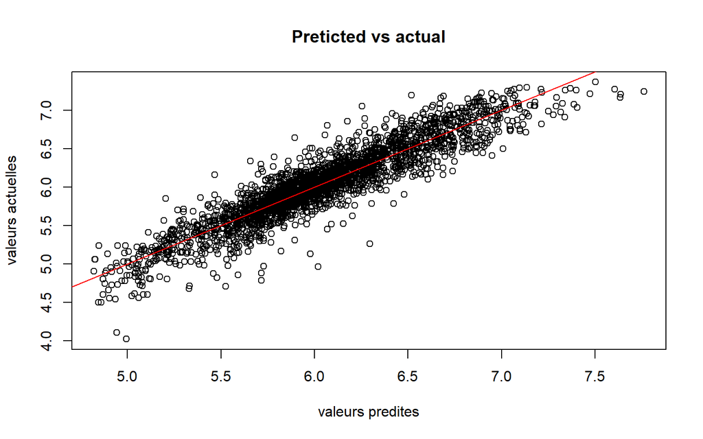

```r
fitted=predict(lm1, data)
plot(data$lognb~fitted,main="Preticted vs actual",xlab="valeurs predites",ylab="valeurs actuelles")
abline(a=0, b=1, col="red")
```

Le modèle est correct.

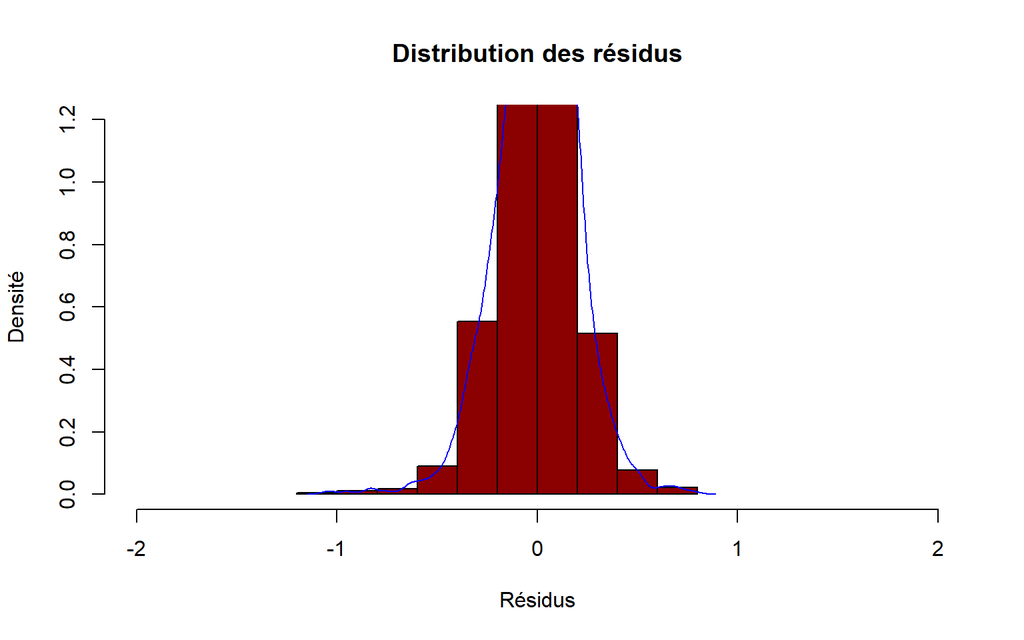

```r
hist(lm1$residuals, freq=FALSE,col="darkred",main="Distribution des résidus",xlab="Résidus",ylab="Densité",xlim=c(-2,2),ylim=c(0,1.2))
lines(density(lm1$residuals),col="blue")
```

La distribution des résidus semble bien suivre la distribution d’une loi normale, ils sont bien centrés sur 0.

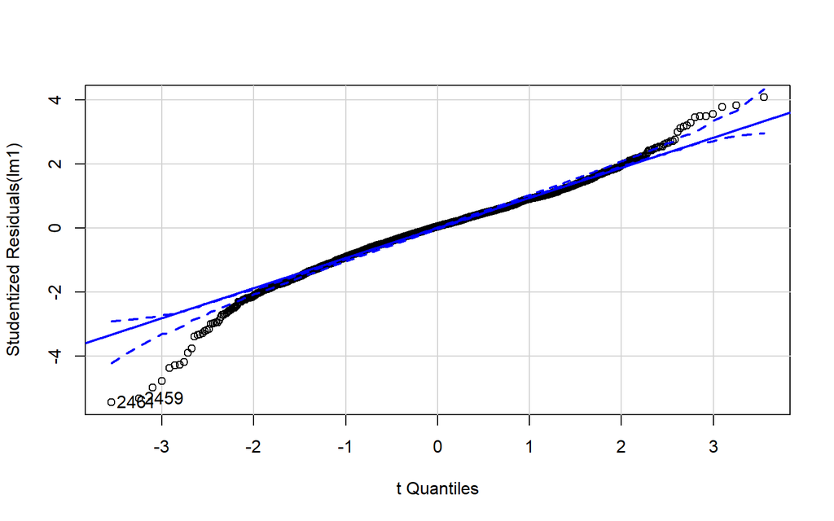

```
## [1] 2459 2461
```

```r
qqPlot(lm1, id.n=2)#2459,2461
```

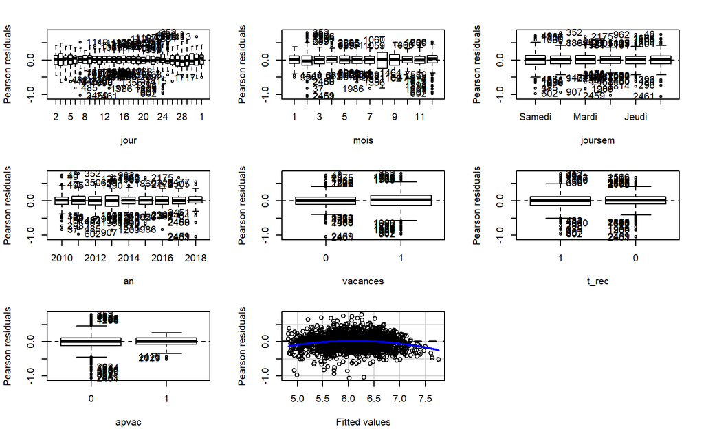

```
##            Test stat Pr(>|Test stat|)
## jour
## mois
## joursem
## an
## vacances
## t_rec
## apvac
## Tukey test    -9.819        < 2.2e-16 ***
## ---
## Signif. codes:  0 '***' 0.001 '**' 0.01 '*' 0.05 '.' 0.1 ' ' 1
```

```r
residualPlots(lm1)
```

Toutes les médianes des résidus semblent être centrées sur 0, ce qui est positif. Toutefois, le dernier grahique montre qu’il reste une forme non linéaire, même si celle si n’est pas trop forte.

```r
head(sort(hatvalues(lm1),decreasing = T))
```

```
##       2536       1717       1167       2023       2433        868
## 0.04886564 0.04877827 0.04825134 0.04817343 0.04724983 0.04656017
```

On regarde toutes les observations avec les plus grands résidus standardisés.

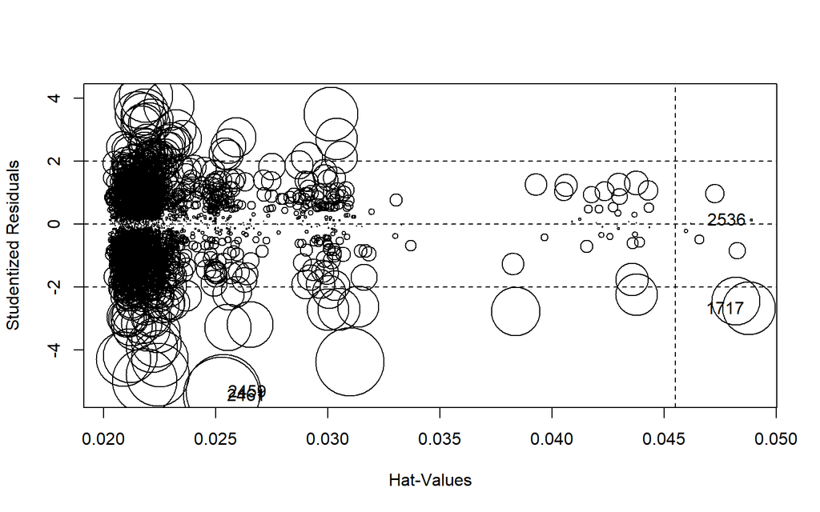

```
##         StudRes        Hat        CookD
## 1717 -2.6748305 0.04877827 6.310124e-03
## 2459 -5.3237389 0.02532159 1.255729e-02
## 2461 -5.4372460 0.02526266 1.306086e-02
## 2536  0.1338095 0.04886564 1.586641e-05
```

```r
influencePlot(lm1)
```

```r
data<-data[-c(2459,2461,2550,2504,1716,1516,2326,2453,2300),]
```

```r
lm1<-lm(lognb~jour+mois+joursem+an+vacances+t_rec+apvac,data=data)
summary(lm1)
```

```
##
## Call:
## lm(formula = lognb ~ jour + mois + joursem + an + vacances +
##     t_rec + apvac, data = data)
##
## Residuals:
##      Min       1Q   Median       3Q      Max
## -0.96820 -0.10974  0.00809  0.11683  0.79035
##
## Coefficients:
##                 Estimate Std. Error t value Pr(>|t|)
## (Intercept)      6.11922    0.02817 217.195  < 2e-16 ***
## jour3           -0.18915    0.02984  -6.338 2.76e-10 ***
## jour4           -0.34994    0.02990 -11.706  < 2e-16 ***
## jour5           -0.39612    0.03014 -13.141  < 2e-16 ***
## jour6           -0.46580    0.02997 -15.544  < 2e-16 ***
## jour7           -0.55750    0.02989 -18.654  < 2e-16 ***
## jour8           -0.68383    0.03068 -22.290  < 2e-16 ***
## jour9           -0.71836    0.03008 -23.881  < 2e-16 ***
## jour10          -0.78517    0.03002 -26.156  < 2e-16 ***
## jour11          -0.84886    0.03060 -27.739  < 2e-16 ***
## jour12          -0.88193    0.02983 -29.565  < 2e-16 ***
## jour13          -0.92956    0.03012 -30.863  < 2e-16 ***
## jour14          -0.94904    0.03065 -30.969  < 2e-16 ***
## jour15          -0.96185    0.03062 -31.409  < 2e-16 ***
## jour16          -0.98301    0.02985 -32.937  < 2e-16 ***
## jour17          -0.97808    0.03011 -32.482  < 2e-16 ***
## jour18          -1.00822    0.02991 -33.713  < 2e-16 ***
## jour19          -0.98669    0.02980 -33.115  < 2e-16 ***
## jour20          -0.77119    0.02999 -25.719  < 2e-16 ***
## jour21          -0.78398    0.02998 -26.153  < 2e-16 ***
## jour22          -0.79270    0.02985 -26.554  < 2e-16 ***
## jour23          -0.78512    0.02971 -26.423  < 2e-16 ***
## jour24          -0.80448    0.02996 -26.856  < 2e-16 ***
## jour25          -0.67542    0.03077 -21.953  < 2e-16 ***
## jour26          -0.63872    0.02980 -21.431  < 2e-16 ***
## jour27          -0.50789    0.02987 -17.005  < 2e-16 ***
## jour28          -0.34771    0.02998 -11.598  < 2e-16 ***
## jour29          -0.19346    0.03053  -6.336 2.79e-10 ***
## jour30           0.01413    0.03046   0.464  0.64282
```

[output cut: 20 more lines]

```
## an2013          -0.01874    0.01737  -1.079  0.28073
## an2014          -0.07909    0.03198  -2.473  0.01347 *
## an2015          -0.13397    0.03195  -4.193 2.85e-05 ***
## an2016          -0.12530    0.03194  -3.923 8.98e-05 ***
## an2017          -0.07272    0.03198  -2.274  0.02306 *
## an2018          -0.03324    0.03595  -0.925  0.35526
## vacances1       -0.10389    0.01150  -9.031  < 2e-16 ***
## t_rec0           0.26689    0.02773   9.624  < 2e-16 ***
## apvac1           0.17646    0.03180   5.549 3.17e-08 ***
## ---
## Signif. codes:  0 '***' 0.001 '**' 0.01 '*' 0.05 '.' 0.1 ' ' 1
##
## Residual standard error: 0.1956 on 2483 degrees of freedom
## Multiple R-squared:  0.8565, Adjusted R-squared:  0.8532
## F-statistic:   260 on 57 and 2483 DF,  p-value: < 2.2e-16
```

Cela nous a donc amélioré le R2, ce qui n’est pas une surprise.

Nous allons maintenant regarder s’il y a de l’autocorrélation et la corriger si nécessaire.

```r
dwtest(lm1)
```

```
##
##  Durbin-Watson test
##
## data:  lm1
## DW = 0.92654, p-value < 2.2e-16
## alternative hypothesis: true autocorrelation is greater than 0
```

```r
lm1<-cochrane.orcutt(lm1,convergence=8,max.iter=100)
dwtest(lm1)
```

```
##
##  Durbin-Watson test
##
## data:  lm1
## DW = 2.1597, p-value = 0.9999
## alternative hypothesis: true autocorrelation is greater than 0
```

On passe donc d’un coefficient de DW de 0.92 à 2.16.

Maintenant, nous allons corriger l’hétéroscédasticité de notre modèle.

```r
data$resi <- lm1$residuals
attach(data)
varfunc.ols <- lm(log(resi^2)~jour+mois+joursem+an+vacances+t_rec+apvac,data=data)

data$varfunc <- exp(varfunc.ols$fitted.values)
lm1cor <- lm(lognb~jour+mois+joursem+an+vacances+t_rec+apvac, weights = 1/sqrt(varfunc), data = data)
summary(lm1cor)
```

```
##
## Call:
## lm(formula = lognb ~ jour + mois + joursem + an + vacances +
##     t_rec + apvac, data = data, weights = 1/sqrt(varfunc))
##
## Weighted Residuals:
##     Min      1Q  Median      3Q     Max
## -3.1725 -0.3496  0.0255  0.3711  2.0664
##
## Coefficients:
##                  Estimate Std. Error t value Pr(>|t|)
## (Intercept)      6.143289   0.026807 229.166  < 2e-16 ***
## jour3           -0.185489   0.031321  -5.922 3.62e-09 ***
## jour4           -0.346528   0.028908 -11.987  < 2e-16 ***
## jour5           -0.392127   0.029403 -13.336  < 2e-16 ***
## jour6           -0.458442   0.029682 -15.445  < 2e-16 ***
## jour7           -0.565452   0.027124 -20.847  < 2e-16 ***
## jour8           -0.676510   0.028751 -23.530  < 2e-16 ***
## jour9           -0.718119   0.028924 -24.828  < 2e-16 ***
## jour10          -0.799125   0.028489 -28.050  < 2e-16 ***
## jour11          -0.858595   0.030265 -28.369  < 2e-16 ***
## jour12          -0.889031   0.028233 -31.489  < 2e-16 ***
## jour13          -0.931235   0.028102 -33.138  < 2e-16 ***
## jour14          -0.959356   0.027605 -34.753  < 2e-16 ***
## jour15          -0.970547   0.028343 -34.243  < 2e-16 ***
## jour16          -1.004219   0.028100 -35.737  < 2e-16 ***
## jour17          -1.004522   0.026884 -37.365  < 2e-16 ***
## jour18          -1.031109   0.028172 -36.601  < 2e-16 ***
## jour19          -1.024120   0.028084 -36.467  < 2e-16 ***
## jour20          -0.801466   0.026561 -30.174  < 2e-16 ***
## jour21          -0.819592   0.027764 -29.520  < 2e-16 ***
## jour22          -0.824325   0.027042 -30.483  < 2e-16 ***
## jour23          -0.818896   0.026332 -31.098  < 2e-16 ***
## jour24          -0.832751   0.029035 -28.681  < 2e-16 ***
## jour25          -0.721285   0.026442 -27.278  < 2e-16 ***
## jour26          -0.683669   0.028876 -23.676  < 2e-16 ***
## jour27          -0.559698   0.029177 -19.183  < 2e-16 ***
## jour28          -0.407987   0.030845 -13.227  < 2e-16 ***
## jour29          -0.235999   0.030528  -7.730 1.54e-14 ***
## jour30          -0.017650   0.029906  -0.590 0.555133
```

[output cut: 20 more lines]

```
## an2013          -0.049789   0.017390  -2.863 0.004230 **
## an2014          -0.119136   0.029702  -4.011 6.23e-05 ***
## an2015          -0.166457   0.029714  -5.602 2.35e-08 ***
## an2016          -0.154445   0.029686  -5.203 2.12e-07 ***
## an2017          -0.104013   0.029588  -3.515 0.000447 ***
## an2018          -0.068582   0.033004  -2.078 0.037816 *
## vacances1       -0.100669   0.010472  -9.613  < 2e-16 ***
## t_rec0           0.291454   0.026342  11.064  < 2e-16 ***
## apvac1           0.176938   0.031241   5.664 1.65e-08 ***
## ---
## Signif. codes:  0 '***' 0.001 '**' 0.01 '*' 0.05 '.' 0.1 ' ' 1
##
## Residual standard error: 0.5767 on 2483 degrees of freedom
## Multiple R-squared:  0.8705, Adjusted R-squared:  0.8675
## F-statistic: 292.7 on 57 and 2483 DF,  p-value: < 2.2e-16
```

```r
bptest(lm1cor)
```

```
##
##  studentized Breusch-Pagan test
##
## data:  lm1cor
## BP = 397.82, df = 57, p-value < 2.2e-16
```

```r
valeurconstante<-exp(6.143289+((0.5727/(2541-57))/2))
valeurconstante
```

```
## [1] 465.636
```

Notre date de référence dans le modèle est le 2 janvier 2010 et le modèle nous donne une prévision de 465 clients pour une valeur réelle de 462 clients.

# Forecasting

```r
datanew$logvalreelles<-log(datanew$"Valeurs réelles")
#mean(`Valeurs réelles`)
```

```r
datanew<-datanew %>% arrange(Date) %>%  mutate(an=year(Date),
                                      mois=month(Date),
                                      jour =day(Date))


datanew$joursem<-c("Vendredi","Samedi","Lundi","Mardi","Mercredi","Jeudi","Vendredi","Samedi","Lundi","Mardi","Mercredi","Jeudi","Vendredi","Samedi","Lundi","Mardi","Mercredi","Jeudi","Vendredi","Samedi","Lundi","Mardi","Mercredi","Jeudi","Vendredi","Samedi","Lundi","Mardi","Mercredi","Jeudi","Vendredi","Samedi","Lundi","Mardi","Mercredi","Jeudi","Vendredi","Lundi","Mardi","Mercredi","Jeudi")
datanew$vacances<-1
datanew$vacances[1:31]<-0
datanew$t_rec<-0
datanew$apvac<-0
#datanew$apferie<-0
#datanew[c(38),10]<-1

an=c(datanew$an)
jour=c(datanew$jour)
joursem=c(datanew$joursem)
mois=c(datanew$mois)
vacances=c(datanew$vacances)
t_rec=c(datanew$t_rec)
apvac=c(datanew$apvac)
#apferie=c(datanew$apferie)

data3<-data.frame(cbind(jour,joursem,mois,vacances,an,t_rec,apvac))

predict<-predict(lm1cor,data3,level=0.95,interval = "confidence")
colnames(predict)<-c("Valeurs prédites","Borne inf","Borne sup")
valeurscorrigees<-((0.5727/(2541-57))/2)
predict<-exp(predict+valeurscorrigees)
predict %>% kable(caption="Résultat de nos prévisions sur les nouvelles données")
```

Résultat de nos prévisions sur les nouvelles données

| Valeurs prédites | Borne inf | Borne sup |
| --- | --- | --- |
| 1012.3905 | 949.8423 | 1079.0575 |
| 480.7201 | 452.9570 | 510.1849 |
| 734.0661 | 693.2110 | 777.3290 |
| 653.7867 | 617.1500 | 692.5984 |
| 602.7570 | 568.9382 | 638.5860 |
| 482.1299 | 457.1441 | 508.4814 |
| 429.2937 | 405.7869 | 454.1622 |
| 234.4322 | 221.4201 | 248.2090 |
| 439.8932 | 414.4922 | 466.8509 |
| 397.7714 | 376.4159 | 420.3384 |
| 375.6739 | 355.7008 | 396.7686 |
| 325.1573 | 308.0895 | 343.1706 |
| 319.9307 | 302.7062 | 338.1352 |
| 176.1024 | 166.6393 | 186.1030 |
| 370.1904 | 350.2132 | 391.3072 |
| 347.5083 | 328.9589 | 367.1038 |
| 427.7293 | 406.2417 | 450.3535 |
| 373.9318 | 354.1371 | 394.8329 |
| 370.3047 | 351.2341 | 390.4107 |
| 211.9582 | 201.2229 | 223.2662 |
| 504.6384 | 479.0387 | 531.6060 |
| 488.4514 | 461.6219 | 516.8403 |
| 544.7125 | 514.5967 | 576.5907 |
| 564.3518 | 531.3210 | 599.4362 |
| 666.9079 | 628.2534 | 707.9407 |
| 472.3100 | 445.2806 | 500.9802 |
| 1087.4654 | 1021.9038 | 1157.2331 |
| 842.0993 | 790.2278 | 897.3756 |
| 706.2057 | 666.1048 | 748.7207 |
| 600.6522 | 565.8784 | 637.5629 |
| 559.3006 | 526.5511 | 594.0870 |
| 258.6931 | 245.1803 | 272.9506 |
| 479.5350 | 453.1152 | 507.4953 |
| 412.2344 | 389.8914 | 435.8576 |
| 382.6689 | 360.8137 | 405.8479 |
| 330.4459 | 312.7805 | 349.1090 |
| 315.2057 | 298.4005 | 332.9572 |
| 360.2205 | 341.0145 | 380.5082 |
| 335.6925 | 318.6234 | 353.6760 |
| 322.0335 | 304.8880 | 340.1432 |
| 288.6902 | 273.3694 | 304.8698 |

```r
predict2<-predict(lm1ter,data3,level=0.95,interval = "confidence")
colnames(predict2)<-c("fit2","lwr2","upr2")
predict2<-exp(predict2+valeurscorrigees)


datanew<-cbind(datanew,predict,predict2)



attach(datanew)
datanew %>% ggvis(~datanew$Date,~datanew$`Valeurs réelles`)%>%
  layer_paths() %>%
  layer_paths(~datanew$Date,~datanew$`Valeurs prédites`, stroke:="red")
```

[output not shown]

```r
datanew %>% ggvis(~datanew$Date,~datanew$`Valeurs réelles`)%>%
  layer_paths() %>%
  layer_paths(~datanew$Date,~datanew$`Valeurs prédites`, stroke:="red") %>%
  layer_paths(~datanew$Date,~datanew$fit2, stroke:="blue")
```

[output not shown]

```r
datanew$difference<-datanew$`Valeurs prédites`-datanew$`Valeurs réelles`
datanew$differencecarree<-datanew$difference^2
SCR=sum(datanew$differencecarree)
datanew$sct<-datanew$`Valeurs réelles`-mean(datanew$`Valeurs réelles`)
datanew$sctcarre<-datanew$sct^2
SCT=round(sum(datanew$sctcarre),2)
SCE=round(sum(datanew$sctcarre)-sum(datanew$differencecarree),2)
R2=round(1-(SCR/SCT),4)
R2
```

```
## [1] 0.9489
```

Le R2 associé à notre prédiction est de 0.9489.

```r
datanew$difference2<-datanew$fit2-datanew$`Valeurs réelles`
datanew$differencecarree2<-datanew$difference2^2
SCR2=sum(datanew$differencecarree2)
datanew$sct2<-datanew$`Valeurs réelles`-mean(datanew$`Valeurs réelles`)
datanew$sctcarre2<-datanew$sct2^2
SCT2=round(sum(datanew$sctcarre2),2)
SCE2=round(sum(datanew$sctcarre2)-sum(datanew$differencecarree2,2))
R22=round(1-(SCR2/SCT2),4)
```

```r
a<-c(mean(datanew$`Valeurs prédites`),mean(datanew$fit2))
b<-c(SCR,SCR2)
c<-c(SCT,SCT2)
d<-c(SCE,SCE2)
e<-c(R2,R22)


matrice<-t(cbind(a,b,c,d,e))
rownames(matrice)<-c("Moyenne de clients","SCR","SCT","SCE","R2")
colnames(matrice)<-c("Modèle lm1cor","Modèle lm1ter")
matrice %>% kable(caption="Difference modèle complet et modèle récent")
```

Difference modèle complet et modèle récent

|  | Modèle lm1cor | Modèle lm1ter |
| --- | --- | --- |
| Moyenne de clients | 470.4449 | 457.4332 |
| SCR | 87152.5609 | 109556.4036 |
| SCT | 1705932.3900 | 1705932.3900 |
| SCE | 1618779.8300 | 1596374.0000 |
| R2 | 0.9489 | 0.9358 |

CORRE BOUDOU

2020-04-24